# Using fluxible with the Li7500

This vignette shows how to process ecosystem fluxes (CO<sub>2</sub> and H<sub>2</sub>O) measured with the LI7500 tent setup presented in Halbritter *et al.* (2024). Because of field constraints, this setup differs from the smaller chamber in several points:

- one file per flux
- start and end of files do not represent start and end of measurements because setting up the tent can take more or less time
- for similar reasons, the length of the measurements is not constant

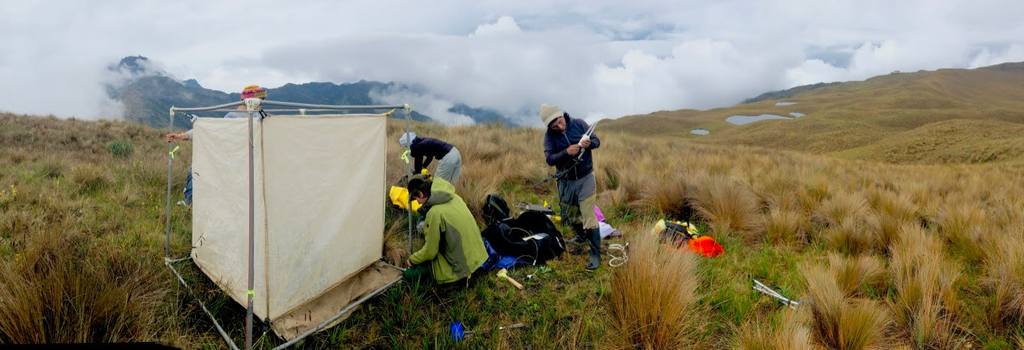

Tent setup

# Importing the files

We import the data with `licoread::import7500`.

```r
library(licoread)
li7500_data <- import7500(
  "ex_data/li7500",
  plotinfo = c("site", "treatment", "date", "plot_id", "trial")
)
```

The `licoread::import7500` function provides `f_start` and `f_end`, meaning we could skip `fluxible::flux_match`. However, `f_start` and `f_end` are based on the start and end of the files, which would require a strict data collection routine. If such a strict routine did not happen, there are two options to deal with that.

## Making a new field record

If `f_start` and `f_end` cannot be used as start and end of measurement, we can recreate a record file (for example in a spreadsheet) with the real start and end datetime:

- use start and end from `licoread::import7500`
- process fluxes until visualization (`flux_fitting`, `flux_quality` and `flux_plot`)
- based on the plots, create a `record` file with metadata identifying the fluxes (`filename`), start and end (note that `flux_match` requires datetime format)
- rename the columns `f_start`, `f_end` and `f_fluxid` to avoid losing those informations (`flux_match` will overwrite them)
- include `flux_match` before `flux_fitting` in your workflow, and match the fluxes with the record file you created
- adapt the record file if necessary and rerun until `flux_plot`
- once satisfied with cutting and fitting, run `flux_calc` as normally

That makes the processing non homogeneous but still reproducible.

## One side is reliable

If the start or the end are consistent but not the other, you can change the direction of the cutting in `flux_fitting`. By default, `flux_fitting` cuts the focus window as `start + start_cut` to `end - end_cut`. The argument `cut_direction` allows to change that:

- `cut_direction = "from_start"` means the focus window will be from `start + start_cut` to `start + end_cut`
- `cut_direction = "from_end"` means the focus window will be from `end - start_cut` to `end - end_cut`

# Processing with `fluxible`

## CO<sub>2</sub>

Wet air correction:

```r
library(fluxible)
li7500_data_co2 <- flux_drygas(li7500_data, `CO2 umol/mol`, `H2O mmol/mol`)
```

Fitting a linear model:

```r
li7500_fits_co2 <- flux_fitting(li7500_data_co2,
                                f_conc = `CO2 umol/mol_dry`,
                                fit_type = "linear")
```

Using `fluxible::flux_quality` to assess the quality of the dataset.

```r
li7500_flags_co2 <- flux_quality(li7500_fits_co2,
                                 f_conc = `CO2 umol/mol_dry`,
                                 rsquared_threshold = 0.5)
```

```
#>
#>  Total number of measurements: 4
#>
#>  ok   4   100 %
#>  discard      0   0 %
#>  zero     0   0 %
#>  force_discard    0   0 %
#>  start_error      0   0 %
#>  no_data      0   0 %
#>  force_ok     0   0 %
#>  force_zero   0   0 %
#>  force_lm     0   0 %
#>  no_slope     0   0 %
```

Plotting:

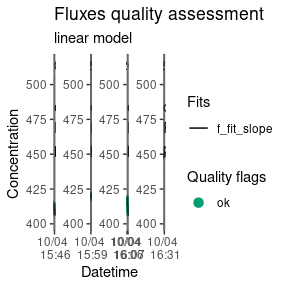

Output of `flux_plot` for CO<sub>2</sub> fluxes

```r
flux_plot(li7500_flags_co2,
          f_conc = `CO2 umol/mol_dry`,
          f_ylim_upper = 500,
          y_text_position = 450,
          print_plot = TRUE)
```

Can be exported in pdf directly (much easier to handle with a lot of data) with:

```r
flux_plot(li7500_flags_co2,
          f_conc = `CO2 umol/mol_dry`,
          f_ylim_upper = 500,
          y_text_position = 450,
          print_plot = FALSE,
          output = "longpdf",
          f_plotname = "li7500_co2")
```

If other data (PAR and co) need processing, that would happen here. To “compress” environmental variables at a single value per flux, see the arguments `cols_ave`, `cols_sum`, and `cols_med` in `fluxible::flux_calc`. To keep the raw data (gas concentration or anything else) in a nested column, see the `cols_nest` argument.

Now let’s calculate the fluxes with `fluxible::flux_calc`.

```r
li7500_fluxes_co2 <- flux_calc(li7500_flags_co2,
                               slope_col = f_slope_corr,
                               temp_air_col = Temperature,
                               setup_volume = 2197,
                               atm_pressure = pressure_atm,
                               plot_area = 1.44,
                               conc_unit = "ppm",
                               flux_unit = "umol/m2/s",
                               cols_keep = c(
                                 "site", "treatment", "date", "plot_id", "trial"
                               ))
```

```
#> Cutting data according to 'keep_arg'...
#> Averaging air temperature for each flux...
#> Creating a df with the columns from 'cols_keep' argument...
#> Calculating fluxes...
#> Concentration was measured in ppm
#> R constant set to 0.082057 L * atm * K^-1 * mol^-1
#> Fluxes are in umol/m2/s
```

## H<sub>2</sub>O

Wet air correction:

```r
li7500_data_h2o <- flux_drygas(li7500_data, `H2O mmol/mol`, `H2O mmol/mol`)
```

Fitting a linear model:

```r
li7500_fits_h2o <- flux_fitting(li7500_data_h2o,
                                f_conc = `H2O mmol/mol_dry`,
                                fit_type = "linear",
                                start_cut = 0,
                                end_cut = 0)
```

Using `fluxible::flux_quality` to assess the quality of the dataset:

```r
li7500_flags_h2o <- flux_quality(li7500_fits_h2o,
                                 f_conc = `H2O mmol/mol_dry`,
                                 rsquared_threshold = 0.5,
                                 ambient_conc = 10, # the default is for CO2
                                 error = 2)
```

```
#>
#>  Total number of measurements: 4
#>
#>  ok   4   100 %
#>  discard      0   0 %
#>  zero     0   0 %
#>  force_discard    0   0 %
#>  start_error      0   0 %
#>  no_data      0   0 %
#>  force_ok     0   0 %
#>  force_zero   0   0 %
#>  force_lm     0   0 %
#>  no_slope     0   0 %
```

Plotting:

[figure not shown]

Output of `flux_plot` for H<sub>2</sub>O fluxes

```r
flux_plot(li7500_flags_h2o,
          f_conc = `H2O mmol/mol_dry`,
          print_plot = TRUE,
          f_ylim_lower = 5,
          f_ylim_upper = 15,
          y_text_position = 12)
```

Or directly exported as a pdf:

```r
flux_plot(li7500_flags_h2o,
          f_conc = `H2O mmol/mol_dry`,
          print_plot = FALSE,
          output = "longpdf",
          f_plotname = "li7500_h2o",
          f_ylim_lower = 5,
          f_ylim_upper = 15,
          y_text_position = 12)
```

Flux calculations:

```r
li7500_fluxes_h2o <- flux_calc(li7500_flags_h2o,
                               slope_col = f_slope_corr,
                               temp_air_col = Temperature,
                               setup_volume = 2197,
                               atm_pressure = pressure_atm,
                               plot_area = 1.44,
                               conc_unit = "mmol/mol",
                               flux_unit = "mmol/m2/s",
                               cols_keep = c(
                                 "site", "treatment", "date", "plot_id", "trial"
                               ))
```

```
#> Cutting data according to 'keep_arg'...
#> Averaging air temperature for each flux...
#> Creating a df with the columns from 'cols_keep' argument...
#> Calculating fluxes...
#> Concentration was measured in mmol/mol
#> R constant set to 0.082057 L * atm * K^-1 * mol^-1
#> Fluxes are in mmol/m2/s
```

# Calculating Gross Primary Production and Transpiration

I’m glad you asked! The function `fluxible::flux_diff` is precisely made for that.

```r
li7500_fluxes_co2 <- flux_diff(li7500_fluxes_co2, type_col = trial,
                               id_cols = c(
                                 "site", "treatment", "date", "plot_id"
                               ), type_a = "p", type_b = "r",
                               diff_name = "GPP", cols_keep = "all")
```

```r
li7500_fluxes_h2o <- flux_diff(li7500_fluxes_h2o, type_col = trial,
                               id_cols = c(
                                 "site", "treatment", "date", "plot_id"
                               ), type_a = "p", type_b = "r",
                               diff_name = "T", cols_keep = "all")
```

# Further calculations

In order to calculate carbon and water use efficiencies, we need both H<sub>2</sub>O and CO<sub>2</sub> fluxes in the same dataset.

```r
library(tidyverse)
# to avoid confusion, we add a gas column
# this might be implemented in flux_calc in the future

li7500_fluxes_co2 <- li7500_fluxes_co2 |>
  mutate(gas = "co2")

li7500_fluxes_h2o <- li7500_fluxes_h2o |>
  mutate(gas = "h2o")

li7500_fluxes <- bind_rows(li7500_fluxes_co2, li7500_fluxes_h2o)

# Now the data are in a single long df
```

[output not shown]

### References

Halbritter, A.H., Vandvik, V., Cotner, S.H., Farfan-Rios, W., Maitner, B.S., Michaletz, S.T., Oliveras Menor, I., *et al.* (2024), “[Plant trait and vegetation data along a 1314 m elevation gradient with fire history in Puna grasslands, Perú](https://doi.org/10.1038/s41597-024-02980-3)”, *Scientific Data*, Nature Publishing Group, Vol. 11 No. 1, p. 225.